# Session 10: Data Science Capstone Project

# Fit a linear regression model

To help you get started I build a linear regression model below. I chose a subset of the features with no particular goal. You can (and should) add more variables and/or choose variable selection methods if you want.

```r
#Define control variables
set.seed(1234)
control <- trainControl (
    method="cv", #cross-validation +5 fold
    number=5, #5- fold cross-Validation
    verboseIter=TRUE) #by setting this to true the model will report its progress after each estimation


#we are going to train the model and report the results using k-fold cross validation
set.seed(1234)
model1_lm<-train(
    price ~ distance_to_station+num_tube_lines+num_rail_lines+
      num_light_rail_lines+average_income+london_zone+property_type+
      whether_old_or_new+freehold_or_leasehold+total_floor_area+
    co2_emissions_current+co2_emissions_potential,
    train_data,
   method = "lm",
    trControl = control
   )
# summary of the results
summary(model1_lm)
```

```
##
## Call:
## lm(formula = .outcome ~ ., data = dat)
##
## Residuals:
##      Min       1Q   Median       3Q      Max
## -1751997  -127376    -8568   100450  7357059
##
## Coefficients:
##                           Estimate Std. Error t value Pr(>|t|)
## (Intercept)             -3.744e+05  3.421e+04 -10.944  < 2e-16 ***
## distance_to_station      8.268e+03  8.505e+03   0.972  0.33095
## num_tube_lines           1.083e+05  5.349e+03  20.248  < 2e-16 ***
## num_rail_lines           1.958e+04  7.735e+03   2.531  0.01138 *
## num_light_rail_lines    -6.222e+03  8.246e+03  -0.755  0.45051
## average_income           8.152e+00  3.939e-01  20.694  < 2e-16 ***
## london_zone             -8.515e+04  2.746e+03 -31.010  < 2e-16 ***
## property_typeF           8.091e+04  2.815e+04   2.874  0.00406 **
## property_typeS           2.628e+04  1.486e+04   1.768  0.07712 .
## property_typeT           7.990e+04  1.489e+04   5.367 8.17e-08 ***
## whether_old_or_newY      4.128e+04  1.285e+05   0.321  0.74810
## freehold_or_leaseholdL  -2.231e+04  2.391e+04  -0.933  0.35082
## total_floor_area         6.989e+03  1.167e+02  59.892  < 2e-16 ***
## co2_emissions_current    5.589e+03  2.376e+03   2.353  0.01866 *
## co2_emissions_potential  2.146e+04  3.395e+03   6.321 2.71e-10 ***
## ---
## Signif. codes:  0 '***' 0.001 '**' 0.01 '*' 0.05 '.' 0.1 ' ' 1
##
## Residual standard error: 314500 on 10483 degrees of freedom
## Multiple R-squared:  0.6226, Adjusted R-squared:  0.6221
## F-statistic:  1235 on 14 and 10483 DF,  p-value: < 2.2e-16
```

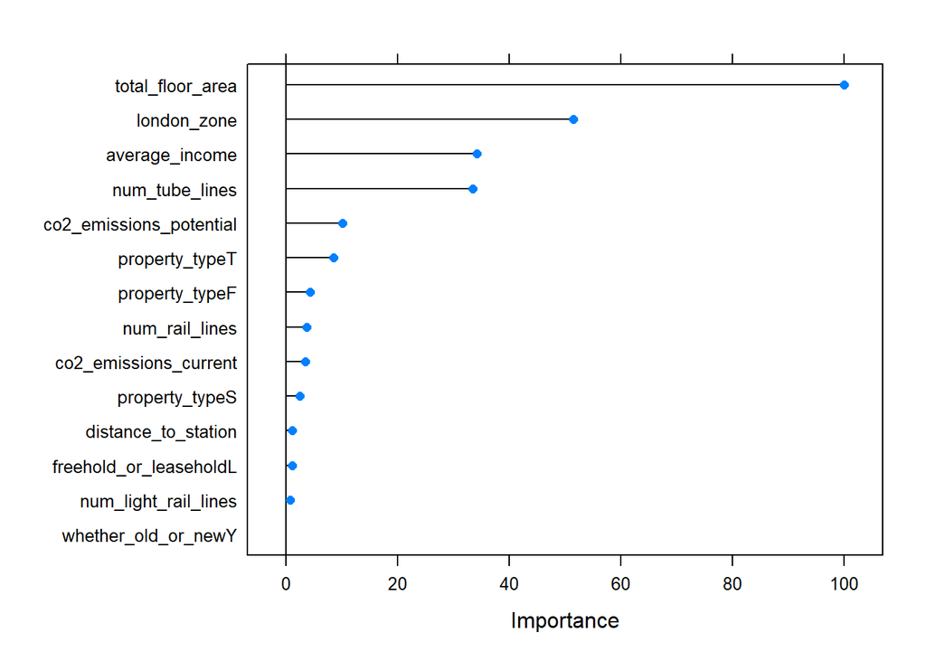

```r
# we can check variable importance as well
importance <- varImp(model1_lm, scale=TRUE)
plot(importance)
```

## Predict the values in testing and out of sample data

Below I use the predict function to test the performance of the model in testing data and summarize the performance of the linear regression model. How can you measure the quality of your predictions?

```r
# We can predict the testing values

predictions <- predict(model1_lm,test_data)

lr_results<-data.frame(RMSE = RMSE(predictions, test_data$price),
                         MAE = MAE(predictions, test_data$price),
                            Rsquare = R2(predictions, test_data$price))


lr_results
```

| RMSE | MAE | Rsquare |
| --- | --- | --- |
| 3.44e+05 | 1.7e+05 | 0.597 |

```r
predictions_lm = predict(model1_lm,testing_d)
result_lm = data.frame(ID = ID_testing, price = predictions_lm)
write.csv(result_lm,'result_lm.csv',row.names = F)
```

```r
#We can predict prices for out of sample data the same way
predictions_oos <- predict(model1_lm,london_house_prices_2019_out_of_sample)
```

# Fit a tree model

Next I fit a tree model using the same subset of features. Again you can (and should) add more variables and tune the parameter of your tree to find a better fit.

Compare the performance of the linear regression model with the tree model; which one performs better? Why do you think that is the case?

```r
set.seed(1234)

model2_tree <- train(
 price ~ distance_to_station+num_tube_lines+num_rail_lines+
      num_light_rail_lines+average_income+london_zone+property_type+
      whether_old_or_new+freehold_or_leasehold+total_floor_area+
    co2_emissions_current+co2_emissions_potential,
  train_data,
  method = "rpart",
  trControl = control,
  tuneLength=10
    )
```

#You can view how the tree performs

```r
model2_tree$results
```

| cp | RMSE | Rsquared | MAE | RMSESD | RsquaredSD | MAESD |
| --- | --- | --- | --- | --- | --- | --- |
| 0.00989 | 2.84e+05 | 0.693 | 1.64e+05 | 2.01e+04 | 0.035 | 8.16e+03 |
| 0.0121 | 2.89e+05 | 0.682 | 1.66e+05 | 1.75e+04 | 0.0275 | 7.18e+03 |
| 0.0178 | 3.08e+05 | 0.64 | 1.79e+05 | 1.79e+04 | 0.033 | 7.91e+03 |
| 0.0179 | 3.08e+05 | 0.64 | 1.79e+05 | 1.79e+04 | 0.033 | 7.91e+03 |
| 0.0336 | 3.26e+05 | 0.6 | 1.86e+05 | 2.07e+04 | 0.0139 | 9.96e+03 |
| 0.0372 | 3.34e+05 | 0.577 | 1.93e+05 | 1.7e+04 | 0.0116 | 4.83e+03 |
| 0.0469 | 3.53e+05 | 0.528 | 1.98e+05 | 2.69e+04 | 0.0231 | 6.95e+03 |
| 0.0559 | 3.63e+05 | 0.501 | 2.07e+05 | 3.48e+04 | 0.0558 | 1.43e+04 |
| 0.14 | 4.08e+05 | 0.368 | 2.3e+05 | 2.73e+04 | 0.0681 | 9.62e+03 |
| 0.323 | 4.76e+05 | 0.301 | 2.61e+05 | 2.35e+04 | 0.00422 | 2.32e+04 |

#You can view the final tree

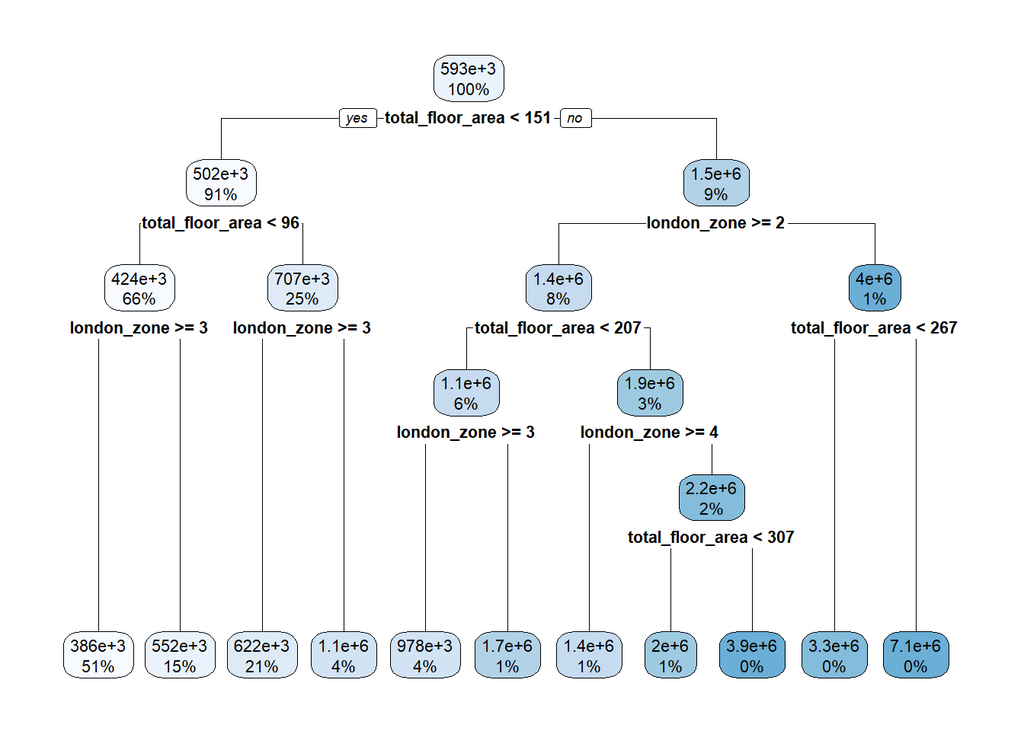

```r
rpart.plot(model2_tree$finalModel)
```

#you can also visualize the variable importance

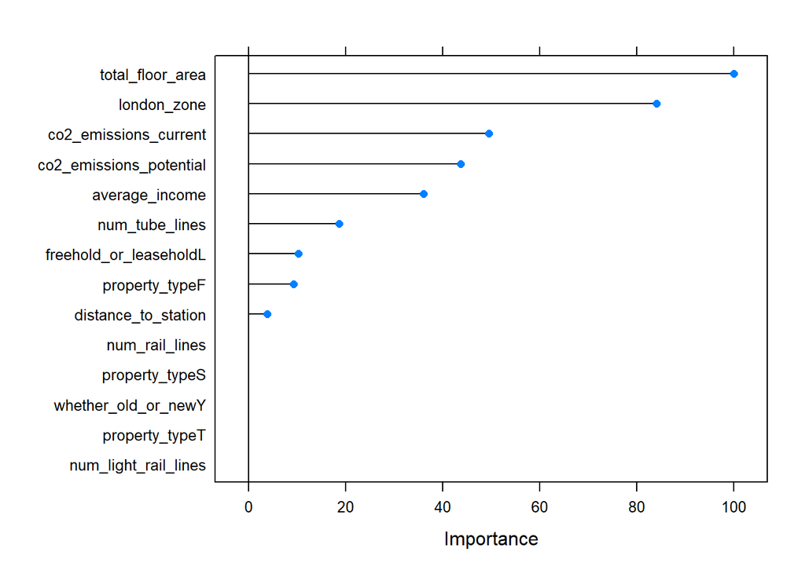

```r
importance <- varImp(model2_tree, scale=TRUE)
plot(importance)
```

```r
#prediction
predictions = predict(model2_tree,test_data)
tree_results = data.frame(RMSE = RMSE(predictions,test_data$price),
                          MAE = MAE(predictions, test_data$price),
                          Rsquare = R2(predictions,test_data$price))
tree_results
```

| RMSE | MAE | Rsquare |
| --- | --- | --- |
| 3.01e+05 | 1.66e+05 | 0.691 |

```r
predictions_tree = predict(model2_tree,testing_d)
result_tree = data.frame(ID = ID_testing, price = predictions_tree)
write.csv(result_tree,'result_tree.csv',row.names = F)
```

# Other algorithms

Use at least two other algorithms to predict prices. Don’t forget to tune the parameters of these algorithms. And then compare the performances of your algorithms to linear regression and trees.

# KNN

```r
set.seed(1234)
model3_KNN = train(price ~ distance_to_station+num_tube_lines+num_rail_lines+
      num_light_rail_lines+average_income+london_zone+property_type+
      whether_old_or_new+freehold_or_leasehold+total_floor_area+
    co2_emissions_current+co2_emissions_potential,
  train_data,
  method = 'knn',
  trControl = control)
model3_KNN$results
```

| k | RMSE | Rsquared | MAE | RMSESD | RsquaredSD | MAESD |
| --- | --- | --- | --- | --- | --- | --- |
| 5 | 3.31e+05 | 0.59 | 1.58e+05 | 3.15e+04 | 0.0334 | 5.7e+03 |
| 7 | 3.38e+05 | 0.582 | 1.59e+05 | 3.17e+04 | 0.0329 | 5.31e+03 |
| 9 | 3.46e+05 | 0.572 | 1.62e+05 | 3.14e+04 | 0.0318 | 5.97e+03 |

[output not shown]

```r
#prediction
predictions = predict(model3_KNN,test_data)
KNN_results = data.frame(RMSE = RMSE(predictions,test_data$price),
                         MAE = MAE(predictions, test_data$price),
                         Rsquare = R2(predictions,test_data$price))
KNN_results
```

| RMSE | MAE | Rsquare |
| --- | --- | --- |
| 3.45e+05 | 1.54e+05 | 0.603 |

```r
predictions_KNN = predict(model3_KNN,testing_d)
result_KNN = data.frame(ID = ID_testing,price = predictions_KNN)
write.csv(result_KNN,'result_KNN.csv',row.names = F)
```

# Random Forest

```r
set.seed(1234)
model4_RF = train(price ~ distance_to_station+num_tube_lines+num_rail_lines+
      num_light_rail_lines+average_income+london_zone+property_type+
      whether_old_or_new+freehold_or_leasehold+total_floor_area+
    co2_emissions_current+co2_emissions_potential,
  train_data,
  method = 'rf',
  trControl = control)
model4_RF$results
```

| mtry | RMSE | Rsquared | MAE | RMSESD | RsquaredSD | MAESD |
| --- | --- | --- | --- | --- | --- | --- |
| 2 | 2.52e+05 | 0.787 | 1.25e+05 | 2.23e+04 | 0.0218 | 7.17e+03 |
| 8 | 2.27e+05 | 0.805 | 1.11e+05 | 1.71e+04 | 0.0115 | 5.39e+03 |
| 14 | 2.28e+05 | 0.802 | 1.12e+05 | 1.95e+04 | 0.0177 | 5.06e+03 |

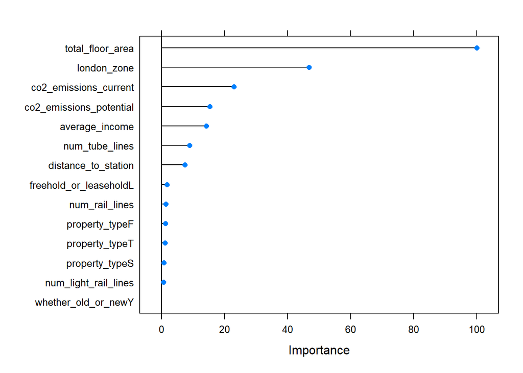

```r
importance = varImp(model4_RF,scale = TRUE)
plot(importance)
```

```r
#prediction
predictions = predict(model4_RF,test_data)
RF_results = data.frame(RMSE = RMSE(predictions,test_data$price),
                        MAE = MAE(predictions, test_data$price),
                        Rsquare = R2(predictions,test_data$price))
RF_results
```

| RMSE | MAE | Rsquare |
| --- | --- | --- |
| 2.39e+05 | 1.14e+05 | 0.807 |

```r
predictions_RF = predict(model4_RF,testing_d)
result_RF = data.frame(ID = ID_testing,price = predictions_RF)
write.csv(result_RF,'result_RF.csv',row.names = F)
```

# Stacking

Use stacking to ensemble your algorithms.

```r
price_lm = predict(model1_lm,train_data)
price_tree = predict(model2_tree,train_data)
price_KNN = predict(model3_KNN,train_data)
price_RF = predict(model4_RF,train_data)
stacking_training = as.data.frame(cbind(price_lm,price_tree,price_KNN,price_RF))

stacking_training$price = train_data$price
model = lm(price~.,data = stacking_training)
```

```r
#prediction
price_lm_pre = predict(model1_lm,test_data)
price_tree_pre = predict(model2_tree,test_data)
price_KNN_pre = predict(model3_KNN,test_data)
price_RF_pre = predict(model4_RF,test_data)
stacking_testing = as.data.frame(cbind(price_lm_pre,price_tree_pre,price_KNN_pre,
                                       price_RF_pre))
colnames(stacking_testing) = colnames(stacking_training)[1:4]
predictions = predict(model,stacking_testing)

stacking_results = data.frame(RMSE = RMSE(predictions,test_data$price),
                            MAE = MAE(predictions, test_data$price),
                           Rsquare = R2(predictions,test_data$price))
stacking_results
```

| RMSE | MAE | Rsquare |
| --- | --- | --- |
| 2.42e+05 | 1.2e+05 | 0.8 |

```r
stacking_oos = as.data.frame(cbind(predictions_lm,predictions_tree,
                                   predictions_KNN,predictions_RF))
colnames(stacking_oos) = colnames(stacking_training)[1:4]
predictions_stacking = predict(model,stacking_oos)
result_stacking = data.frame(ID = ID_testing,pre_price = predictions_stacking)
write.csv(result_stacking,'result_stacking.csv',row.names = F)
```

# Pick investments

In this section you should use the best algorithm you identified to choose 200 properties from the out of sample data.

```r
oos = read_csv('test_data_assignment.csv')

investment_d=oos%>%
  left_join(result_RF)%>%
   mutate(profit = (price-asking_price)/asking_price)

head(-sort(-investment_d$profit),n=200)
```

```
##   [1] 3.8896541 3.8877765 2.9846397 2.7532594 2.5951658 2.3105253 2.3082689
##   [8] 1.9997633 1.9821693 1.7506559 1.7301525 1.6892515 1.5739285 1.5275123
##  [15] 1.4168358 1.3985745 1.3984526 1.3887053 1.3514852 1.3064797 1.2673331
##  [22] 1.2343429 1.2290978 1.2241201 1.2119307 1.2067392 1.2014013 1.1406112
##  [29] 1.0806053 1.0623848 1.0550280 1.0544816 1.0448785 1.0439246 1.0420024
##  [36] 0.9881740 0.9844163 0.9671459 0.9593023 0.9507278 0.9446950 0.9384304
##  [43] 0.9318441 0.9063677 0.8932756 0.8890606 0.8866554 0.8790699 0.8732248
##  [50] 0.8546365 0.8537836 0.8507825 0.8493824 0.8455331 0.8452972 0.8371036
##  [57] 0.8342120 0.8282322 0.8256063 0.8210602 0.8209765 0.8016121 0.7967997
##  [64] 0.7922766 0.7888911 0.7883472 0.7861379 0.7731468 0.7628452 0.7380073
##  [71] 0.7373209 0.7215041 0.7198887 0.7106923 0.7049661 0.7041580 0.6992968
##  [78] 0.6980456 0.6848648 0.6806644 0.6782894 0.6752056 0.6573963 0.6567034
##  [85] 0.6542815 0.6505775 0.6427805 0.6416697 0.6344197 0.6343517 0.6322365
##  [92] 0.6302646 0.6249339 0.6196567 0.6152408 0.6142866 0.6123226 0.6063154
##  [99] 0.6045355 0.6032904 0.6029731 0.5975488 0.5966198 0.5945002 0.5860699
## [106] 0.5850014 0.5848220 0.5827798 0.5825329 0.5766315 0.5713603 0.5652069
## [113] 0.5623999 0.5569139 0.5540182 0.5517319 0.5498014 0.5483762 0.5471432
## [120] 0.5460536 0.5458529 0.5428809 0.5425333 0.5423147 0.5329608 0.5273954
## [127] 0.5213046 0.5206205 0.5184620 0.5183358 0.5178107 0.5165431 0.5090246
## [134] 0.5086779 0.5035621 0.5034407 0.5022302 0.5020553 0.5020425 0.5006898
## [141] 0.4998699 0.4995399 0.4973190 0.4957810 0.4949006 0.4943980 0.4933844
## [148] 0.4903058 0.4840616 0.4823659 0.4813113 0.4795664 0.4789283 0.4785347
## [155] 0.4779481 0.4771814 0.4740312 0.4732995 0.4731292 0.4718034 0.4716811
## [162] 0.4711156 0.4696339 0.4690229 0.4664660 0.4661753 0.4659918 0.4637173
## [169] 0.4617440 0.4610331 0.4584393 0.4577443 0.4534191 0.4496951 0.4481443
## [176] 0.4478579 0.4453493 0.4450948 0.4440592 0.4434390 0.4424924 0.4396249
## [183] 0.4375273 0.4360914 0.4326578 0.4318587 0.4284190 0.4269239 0.4251057
## [190] 0.4247684 0.4247012 0.4245059 0.4233171 0.4221583 0.4210762 0.4203791
## [197] 0.4199099 0.4183147 0.4176033 0.4160791
```

```r
#predict the value of houses
#oos$predict <- predict(model4_RF,oos)
#Choose the ones you want to invest here
#Make sure you choose exactly 200 of them

investment_d$buy<-ifelse(investment_d$profit>=0.4105,1,0)
investment_d <- investment_d %>% select(-price,-profit)

#nrow(investment_d$buy>1)

#output your choices. Change the name of the file to your "lastname_firstname.csv"
write.csv(investment_d,"Zheng_Yiwei.csv")
```